# US Companies Stock Market Prediction - Post Recession

## Citadel Chicago Datathon - Summer 2017

### Akash, Aman, Hang, **Nima** - Team 17

## 1. Problem Statement

Predicting stock price trends by interpreting the seemingly chaotic market data has warranted investigation by both investors and researchers. Among the multitude of methods that have been employed to model this dependence, machine learning techniques are the most popular by far, owing to the capability of identifying stock trends from massive amounts of data that capture the underlying stock price dynamics. As we all know, trading firms keep iterating their models as market and economic conditions vary. As a result, there are no universal equity models and evaluation standards.

In this datathon, with the huge range of datasets available to us, we decided to try and model the financial trends of a company by finding correlations with it's recruitment needs and economic trends of the state it is based out of. Hence, the question we tackled in this datathon is **Can we predict a company's stock prices on the basis of its job posting activity and the economic conditions of the state it is based in**.

### 1.1. Significance

Stock trading is one of the main investment activities in the business market. In the past, in order to maximize benefits,investors have developed several stock analysis algorithms that can help them forecast the movement of the stock price. Whether stocks will rise or fall in a certain period of time is invaluable information to the investors. Predicting the direction of stock prices is particularly important for value investing.

We believe answering the question we have formulated may be a major piece of the stock market puzzle and is vital in deepening our understanding of the relationship between economic trends of a state and their effect on the stock pricing of companies based in that state. Therefore, prediction of stock prices by modeling its correlations with economic conditions and job posting activity can serve as a strong predictive tool for investors.

### 1.2. Datasets

To analysis the relationship between stock prices and the job openings and economic parameters we need to use the following datasets:

| Data | Description |
| --- | --- |
| **jobs** | Job openings data (title, company, location, category, dates, etc.) for over 400 companies from August 2007 to December 2015. |
| **companies** | Important details (name, scrape dates, location, tickers, sectors, etc.) on various companies. |
| **econ_state** | Economic data (GDP, per capita income, unemployment rate, etc.) for all 50 states and the District of Columbia, taken from 1980 – 2016. |
| **geographic** | Latitude and longitude data organized alphabetically by city and state. |
| **financial** | Time series of financial data (close price, ex-dividends, split adjustments, adjusted close price) for over 3,000 stocks on U.S. exchanges, taken from 2007 – 2016. |

Moreover, we created some other sub datasets using above-mentioned data.

## 2. Non-Technical Executive Summary

In this section we focus on Exploratory Data Analysis (EDA) to determine the importance of the features and then we do some feature engineering based on the results of this section.

### 2.1. Interactive Geographical distribution of job openings and stock prices

Here we focus on the top 5 industries based on the frequesny of their job openings: (1) General Management and Business, (2) Accounting and Finance, (3) Restaurants and Food Services, (4) Technology, (5) Retail. In the following bar plot, the X-axis is the unique category ID for industies and the y-axis is the number of job posts:

```python
import matplotlib
import numpy as np
import matplotlib.pyplot as plt
%matplotlib inline
import tensorflow as tf
import pandas as pd
import seaborn as sns

df_jobs = pd.read_csv('/mnt/c/Users/nsalehi/Desktop/Datathon/jobs.csv')
```

```
<Container object of 143 artists>
```

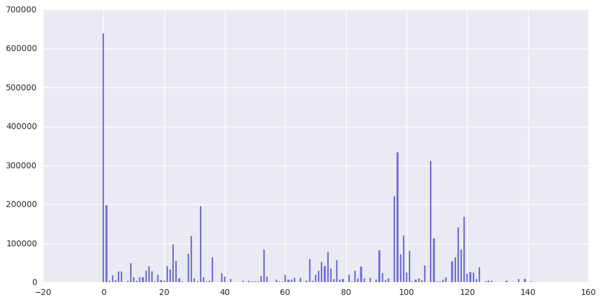

```python
plt.figure(figsize=(12,6))
df_jobs_cat = df_jobs['category_id'].dropna()
df_jobs_cat = pd.Series.to_frame(df_jobs_cat)
df_jobs_cat.columns=['category_id']

df_job_count = df_jobs_cat.groupby('category_id').size()

bar_width=0.4
plt.bar(np.arange(0,len(df_job_count))-0.5*bar_width,df_job_count, alpha=0.5, width = bar_width, color= 'b', label='Number of jobs in Cat ID')
```

We normalized the number of job posts for these five top industries and plot them over the U.S. map based on their zip codes

```python
df_zip = pd.read_csv('/mnt/c/Users/nsalehi/Desktop/Datathon/zipcodes.csv')
```

```python
df_top5 = df_jobs.loc[(df_jobs['category_id'] == 46) | (df_jobs['category_id'] == 1) | (df_jobs['category_id'] == 122) | (df_jobs['category_id'] == 141) | (df_jobs['category_id'] == 127)]
```

```python
df_top5_gr = df_top5[['zip','category_id']].groupby(['zip','category_id']).size()
df_top5_gr = df_top5_gr.reset_index()
df_top5_map = pd.merge(df_top5_gr, df_zip, how='inner', left_on = 'zip', right_on = 'ZIP')
df_top5_map.columns = ['zip', 'category_id', 'count', 'ZIP', 'LAT', 'LNG']
```

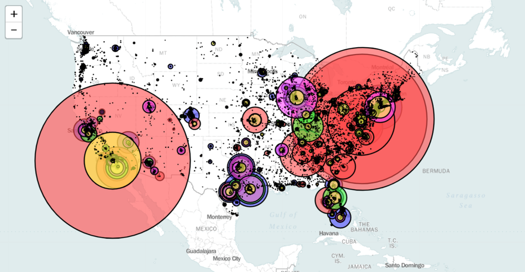

```python
from IPython.display import Image
Image("/mnt/c/Users/nsalehi/Desktop/Datathon/4444.png")
```

The colors in the map represents the industries as follows:

| Color | Industry |
| --- | --- |
| **Blue** | Retail |
| **Red** | Technology |
| **Green** | Restaurants and Food Services |
| **Purple** | Accounting and Finance |
| **Yellow** | General Management and Business |

Moreover, the radius of the circles represent the normalized number of postings. As we can see in the map the job openings for tech industry is aggregated mostly in west and east coast while accounting and finance jobs are more distributed in midwest. The other industries have lower number of jobs openings in compare to these three. We can conclude that the job openings are very location specific.

### 2.2. Relationship between Job Opennings and Overal Return

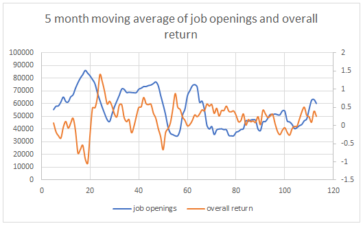

```python
from IPython.display import Image
Image("/mnt/c/Users/nsalehi/Desktop/Datathon/image_1.png")
```

### 2.3. Key Findings

Based on initial analysis of our chosen datasets, we established that state-wise job posting data can provide invaluable insight into the dynamics of stock pricing of a company. Also, economic parameters such as GDP, income and unemployment rate seem to be closely related with stock pricing trends.

These findings can be logically explained as follows. One of the factors that has a strong correlation with stock prices is inflation. Although inflation manifests itself in a variety of ways, most common indicators of inflation include the GDP, per capita income and employment rate. Hence intuitively, the trends in these economic parameters must show up in the trends we witness in stock prices. Also, The job posting data of a company indicates its financial well-being and is expected to have some correlation with stock pricing of the company.

Training our model based on the information obtained from job activity data of companies and economic trends of states, we are able to predict with reasonable accuracy, the stock price trends of our validation dataset. This points towards the fact that the economic conditions of the state in which major part of operations of a company are performed, plays a major role in deciding the fluctuations in stock pricing of the company. Hence, keeping track of job opening postings of a company and the economic growth can drive decision-making for investors.

## 3. Technical Executive Summary

### 3.1. Linear Model

Our data is related to time sequence. There are several algorithms addressing time series data model. We first use multivariate linear regression model to fit data. The linear regression has a better perform on the computation efficiency, it also results in a pretty good predictive accuracy. Then we turn to ridge regression model. Both of these two linear models give us good result as showed below.

### 3.2 Ensemble Method

#### 3.2.1 Method introduction

We have tried some of the single models such as Multiple Linear Regression, Ridge Linear Regression. Beyond single models, we decided to turn to ensemble methods to improve the prediction performance. We achieved fairly good results by using linear models. We would like to ensemble linear models as weak learners by using ensemble method. Boost model can incorporate not just decision tree, but also linear model compared to Random Forest. Thus, Boost methods are appropriate here. Specifically, we chose to use XGBoost model here to build our model to this prediction problem. We chose XGBoost here instead of an another popular boosting method which was taught in the class, Adaboost, because, firstly XGBoost is more flexible, i.e. it has more customizable parameters. Secondly, XGboost is much faster compared to most of implementations of AdaBoost. Thirdly, Gradient Boosting model works for generic loss functions, while Adaboost is derived mainly for classification with exponential loss.

#### 3.2.2 Model Selection

###### 3.2.2.1 Model Parameters

In order to build the XGBoost model, we need to select several parameters, we listed the parameters in the following table:

[output not shown]

#### 3.2.2 Validation

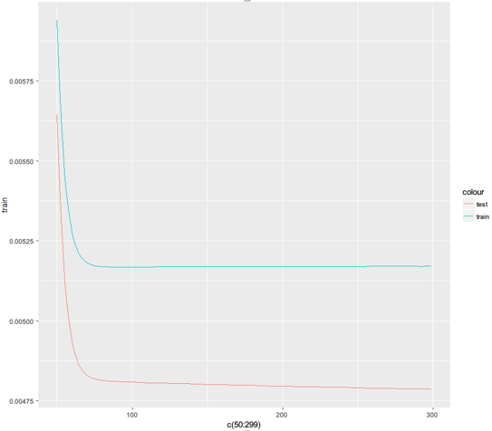

```python
from IPython.display import Image
Image("/mnt/c/Users/nsalehi/Desktop/Datathon/2222.png")
```

We computed the performance by RMSE for the 80/20 Validation. We can find the both the performance is no better than the single models which we have tried in the previous section.

### 3.3 Test Result

[figure not shown]

```python
from IPython.display import Image
Image("/mnt/c/Users/nsalehi/Desktop/Datathon/1111.png")
```

```python
from IPython.display import HTML

HTML('''<script> $('div.input').hide()</script>''')
```